# Riqueza de Strigiformes en Parques Nacionales de EEUU

Matías Barceló C.

Los buhos (Strigiformes) son un grupo importante dentro de las redes tróficas. Son considerados depredadores topes, dado que se alimentan tanto de aves como de roedores. Estas aves son muy sensibles al cambio de uso de suelo, por lo que es importante realizar medidas de conservación sobre ellas.

Dentro de las acciones básicas en terminos de conservación de la biodiversidad, son la creación de áreas protegidas. Las áreas protegidas cumplen la funcion de disminuir las presiones humanas sobre las especies, por lo tanto la creación de áreas protegidas ayuda a conservar la biodiversidad.Actualmente, muchas especies se encuentran amenazadas dentro de los parques. En el caso de los búhos, solo *Strix occidentalis lucida* y *Strix occidentalis caurina* presentan la categoría de *amenazada*. Las especies de búhos que se encuentran en esta categoría, están presentes diferentes parques nacionales. De un total de 56 parques en EEUU, solo 11 albergan especies en la categoría mencionada (Tabla 1).

Tabla 1. Especies presentes en Parques Nacionales que se encuentran bajo la categoría de Amenazadas

| ParkName | Scientific Name |
| --- | --- |
| Canyonlands National Park | Strix occidentalis lucida |
| Capitol Reef National Park | Strix occidentalis lucida |
| Crater Lake National Park | Strix occidentalis caurina |
| Death Valley National Park | Strix occidentalis caurina |
| Grand Canyon National Park | Strix occidentalis lucida |
| Guadalupe Mountains National Park | Strix occidentalis lucida |
| Mesa Verde National Park | Strix occidentalis lucida |
| Mount Rainier National Park | Strix occidentalis caurina |
| North Cascades National Park | Strix occidentalis caurina |
| Olympic National Park | Strix occidentalis caurina |
| Zion National Park | Strix occidentalis lucida |

Otro aspecto relevante, es que las áreas protegidas cuenten con una superficie tal que permita el normal funcionamiento del ecosistema, y se espera que áres protegidas con mayor tamaño albergen un mayor número de especies.

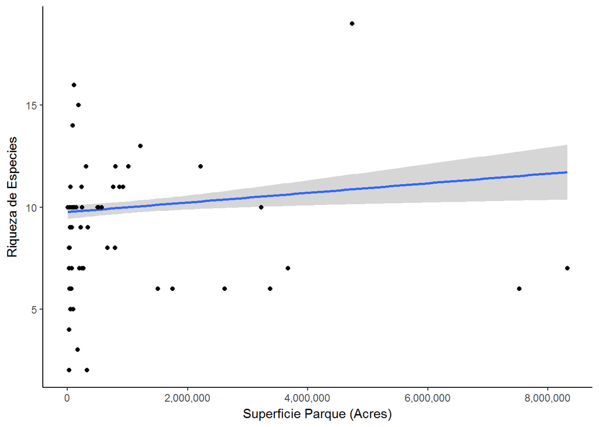

Figura 1. Relación entre la superficie de los parques nacionales de EEUU y la riqueza de especies de búhos

En promedio, cada parque tiene 9 especies, donde la riqueza mayor es de 19 y la menor es de 2 especies.

En este sentido, habría que ahondar más a nivel espacial y de conectividad para entender la gran diversidad de buhós en algunos sitios, a pesár de su baja supercie protegida (Figura 1).

Para poder comprender de mejor manera la relación entre riqueza y parques nacionales, es necesario contar con datos de abundancia, conectividad entre sitios para tener mas certeza en cuanto a generar conclusiones.